# Sydney Bruce QBIO310 HW#1

Loading the file and making sure its loaded properly

```r
clevheart = read.csv("ClevelandHeart.csv")
dim(clevheart)
```

```
[1] 303  12
```

Plotting a histogram of the patients’ resting BP

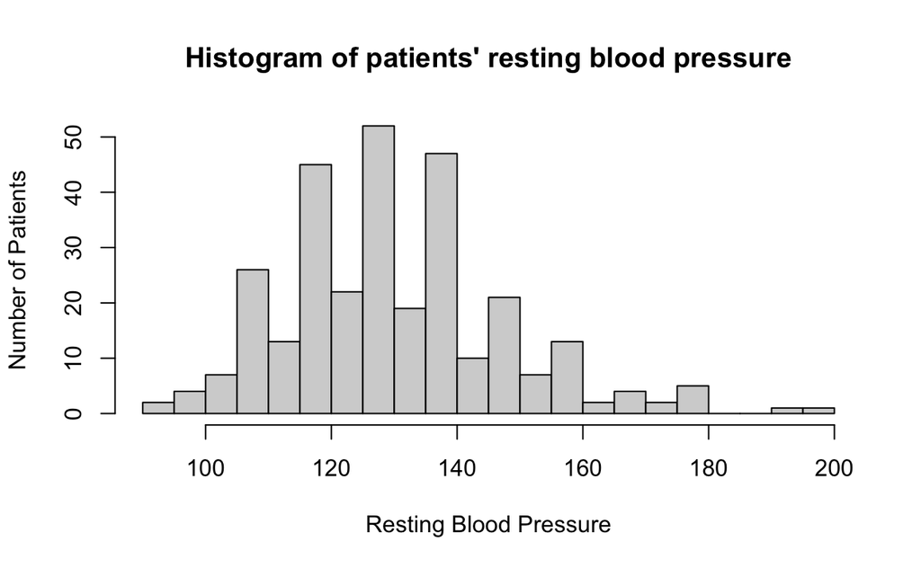

```r
hist(clevheart$RestBP,xlab="Resting Blood Pressure",ylab="Number of Patients",main="Histogram of patients' resting blood pressure",breaks=20)
```

Plotting a histogram of the patients’ maximum HR

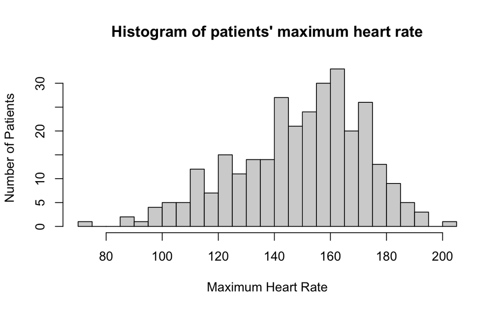

```r
hist(
  clevheart$MaxHR,
  xlab="Maximum Heart Rate",
  ylab="Number of Patients",
  main="Histogram of patients' maximum heart rate",
  breaks=20)
```

Displaying how many pts in dataset, how many have heart disease + fraction, as well as a table displaying chest pain types for negative/positive heart disease patients Trends between negative/positive heart disease diagnoses: Patients without diagnosed heart disease have much higher rates of nonanginal and nontypical chest pain, while patients with diagnosed heart disease have much higher rates of asymptomatic chest pain.

```r
num_pts <- nrow(clevheart)
cat("Number of patients: ",num_pts,"\n")
```

```
Number of patients:  303
```

```r
hd_pts <- clevheart[clevheart$AHD == "Yes",]
nhd_pts <- nrow(hd_pts)
cat("Number of patients with diagnosed heart disease: ",nhd_pts,"\n")
```

```
Number of patients with diagnosed heart disease:  139
```

```r
fhd_pts <- nhd_pts/num_pts
cat("Fraction of patients with diagnosed heart disease: ",fhd_pts,"\n")
```

```
Fraction of patients with diagnosed heart disease:  0.4587459
```

```r
table(clevheart$AHD == "Yes",clevheart$ChestPain)
```

```
        asymptomatic nonanginal nontypical typical
  FALSE           39         68         41      16
  TRUE           105         18          9       7
```

Plotting a histogram with the maximum HR for pts w/ HD:

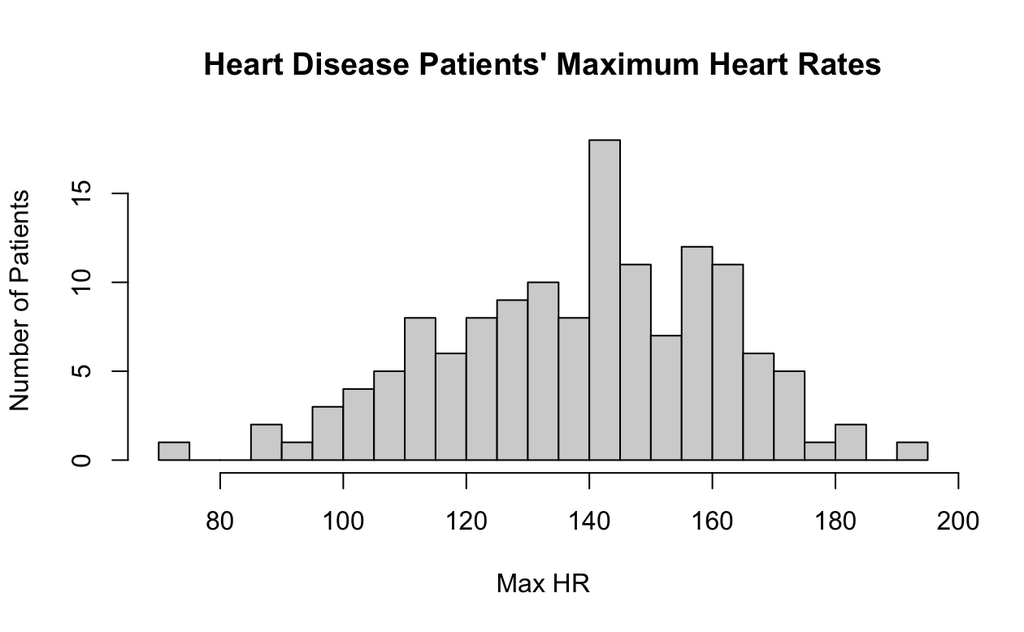

```r
hist(
  clevheart$MaxHR[clevheart$AHD=="Yes"],
  xlab="Max HR",
  ylab="Number of Patients",
  main="Heart Disease Patients' Maximum Heart Rates",
  breaks=20)
```

2a. Making a histogram of 10,000 uniform random variables

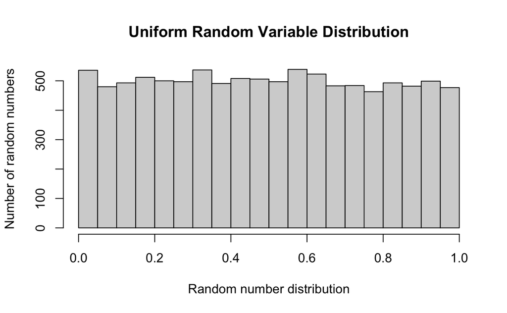

```r
x=runif(10000)
hist(
  x,
  xlab="Random number distribution",
  ylab="Number of random numbers",
  main="Uniform Random Variable Distribution",
  breaks=20) # 2a
```

2b. Writing a function for and taking the mean of a vector of data (URVs) and a vectors of thresholds(defined)

```r
thresholds <- c(0.25,0.5,0.75,1.0)
below_threshold <- function(data,thresholds) {
  sapply(thresholds,function(thresh) {
    # sapply APPLIES the thresholds vector to the function and iterates through thresh
    mean(data<=thresh) # taking the mean of data less than or equal to the current thresh number
    # <= to it, then taking the mean of the returned true values (default)
  })
}
fractions<-below_threshold(x,thresholds)
fractions # 2b
```

```
[1] 0.2521 0.5060 0.7586 1.0000
```

2c. Writing a function for two numbers, m & n…fxn will output an n-length vector…for each element of the return vector the fxn will simulate m URVs and compute the mean

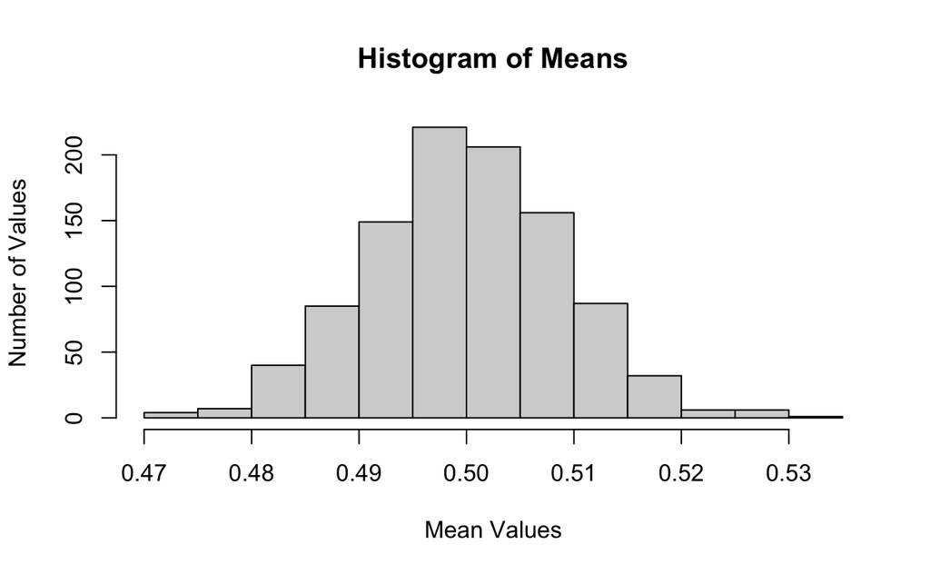

```r
simulate_means <- function(m,n) {
  means<-sapply(1:n, function(i) {
    # appyling 1 through n to the function and iterating through i
    # for 1 through n, simulate m random variables and compute the mean
    mean(runif(m)) # taking the mean of the simulated uniform distribution
  })
  hist(
    means,
    xlab="Mean Values",
    ylab="Number of Values",
    main="Histogram of Means",
    breaks=20)
  return(means)
}
out1 <- simulate_means(1000,1000)
```

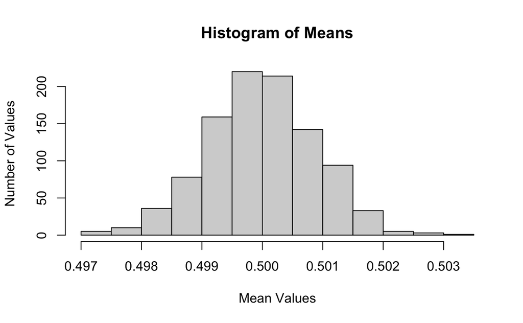

```r
out2 <- simulate_means(100000,1000) # 2c
```

```r
# When m increases, the x-axis range decreases and the variability of the
# mean decreases because of the more concentrated distribution
```

2d. Simulating 10,000 exponential random variables with rate=1 then plot histogram

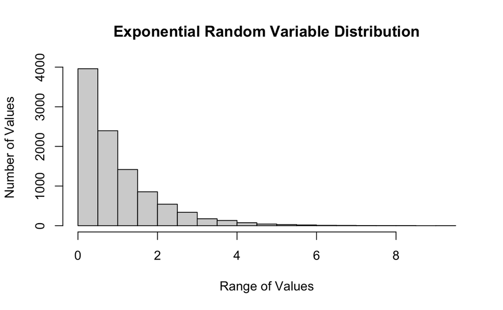

```r
y=rexp(10000,rate=1) # simulate exponential random variables with rate of 1
hist(
  y,
  xlab="Range of Values",
  ylab="Number of Values",
  main="Exponential Random Variable Distribution",
  breaks=20) # 2d
```

Problem 3 3a.

```r
cv<-read.csv("key-countries-pivoted.csv")
dim(cv)
```

```
[1] 816   9
```

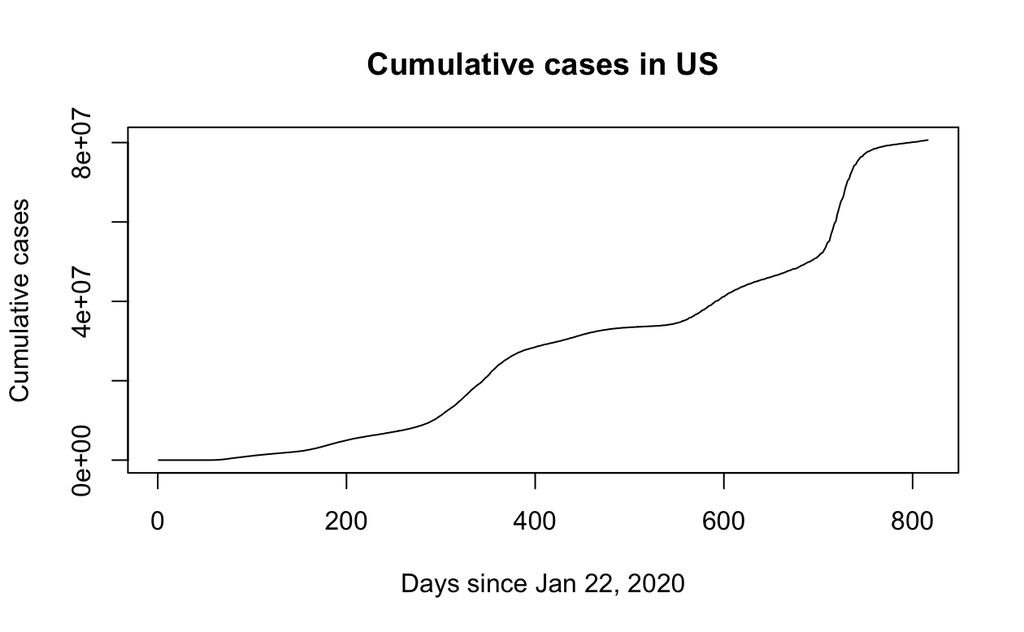

```r
plot(
  cv$US,
  type="l",
  xlab="Days since Jan 22, 2020",
  ylab="Cumulative cases",
  main="Cumulative cases in US")  # 3a
```

```r
# type="l" sets the plot to be a line graph
```

3b.

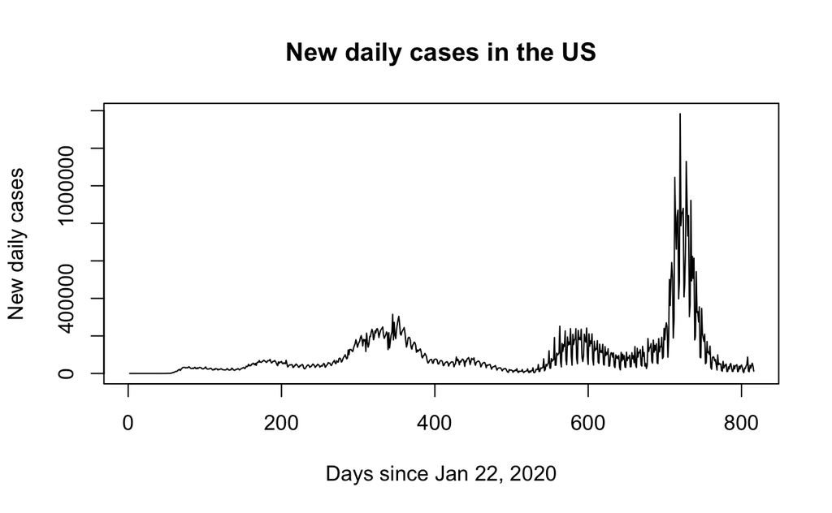

```r
new_cases_US=c(NA,diff(cv$US))
#print(new_cases_US)
plot(
  new_cases_US,
  type="l",
  xlab="Days since Jan 22, 2020",
  ylab="New daily cases",
  main="New daily cases in the US") # 3b
```

3c.

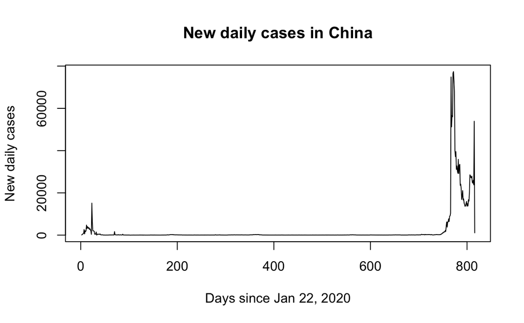

```r
new_cases_C=c(NA,diff(cv$China)) # c to combine (making a new vector), diff steps forward but computes backwards...need NA to ignore 1st value so NA isn't returned in data (if we start at 1 it can't take the difference between 1 and null)
plot(
  new_cases_C,
  type="l",
  xlab="Days since Jan 22, 2020",
  ylab="New daily cases",
  main="New daily cases in China") # 3c
```

3d.

```r
ap16<-which(cv$Date=="2022-04-16") # creating quick call
total_cases_ap16=colSums(cv[ap16,2:ncol(cv)])
# Need to exclude date column (1)...call won't work because not numeric same type
print(total_cases_ap16) # Prints total cases for each country because of colSums above
```

```
         China             US United_Kingdom          Italy         France
       1760211       80625120       21916961       15659835       27874269
       Germany          Spain           Iran
      23416663       11627487        7205064
```

```r
fractions=total_cases_ap16/sum(total_cases_ap16) # Prints total cases for each
# country because is vector ("list" of names that equal a value)
print(fractions)
```

```
         China             US United_Kingdom          Italy         France
   0.009260096    0.424151623    0.115300474    0.082383064    0.146640606
       Germany          Spain           Iran
   0.123190088    0.061169738    0.037904311
```

```r
populations<-c( # setting population numbers for each country
  China=1412000000,
  US=332000000,
  United_Kingdom=67000000,
  Italy=59000000,
  France=68000000,
  Germany=83000000,
  Spain=47000000,
  Iran=88000000
)

case_per_country<-total_cases_ap16/populations
# does on per country standard bcz both are vectors
cases_table<-data.frame( # creates new data.frame to present the information
  Country=names(case_per_country),
  FractionTotal=as.numeric(fractions),
  CasesPerCapita=as.numeric(case_per_country),
  Population=as.numeric(populations)
)
print(cases_table) # 3d
```

| Country | FractionTotal | CasesPerCapita | Population |
| --- | --- | --- | --- |
| China | 0.009260096 | 0.001246608 | 1.412e+09 |
| US | 0.424151623 | 0.242846747 | 3.320e+08 |
| United_Kingdom | 0.115300474 | 0.327118821 | 6.700e+07 |
| Italy | 0.082383064 | 0.265420932 | 5.900e+07 |
| France | 0.146640606 | 0.409915721 | 6.800e+07 |
| Germany | 0.123190088 | 0.282128470 | 8.300e+07 |
| Spain | 0.061169738 | 0.247393340 | 4.700e+07 |
| Iran | 0.037904311 | 0.081875727 | 8.800e+07 |

```r
nrow(cv)
```

```
[1] 816
```